```r
library(ggplot2)
library(Hmisc)
library(scales)
```

## Read in the dataset

```r
if(!file.exists('datasets/activity.csv')){
    url <- "http://d396qusza40orc.cloudfront.net/repdata%2Fdata%2Factivity.zip"
    download.file(url, destfile="datasets/activity.zip", mode="wb", quiet=FALSE)
    unzip('activity.zip')
}
DataFile <- read.csv(file='datasets/activity.csv')
```

### Calculate the mean steps and median steps per day

- Calculate the total number of steps taken per day
- Make a histogram of the total number of steps taken each day
- Calculate and report the mean and median of the total number of steps taken per day

```r
steps <- tapply(DataFile$steps, DataFile$date, sum, na.rm=TRUE)
```

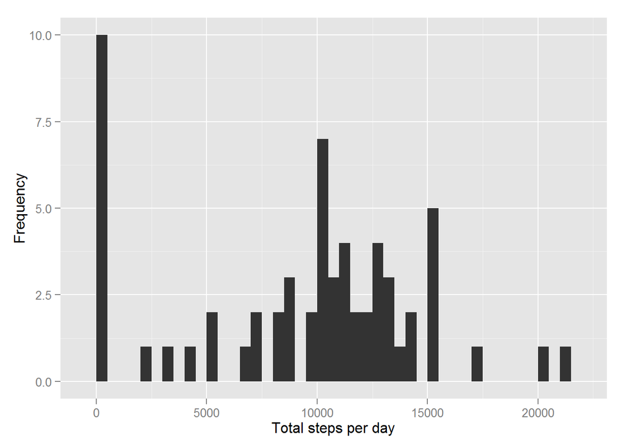

```r
qplot(steps, geom="histogram", xlab='Total steps per day', ylab='Frequency', binwidth=500)
```

```r
meansteps <- mean(steps)
mediansteps <- median(steps)
```

mean steps is 9354.2295082  
median steps is 10395

### What is the average daily activity pattern?

- Make a time series plot
- Which 5-minute interval, on average across all the days in the dataset, contains the maximum number of steps?

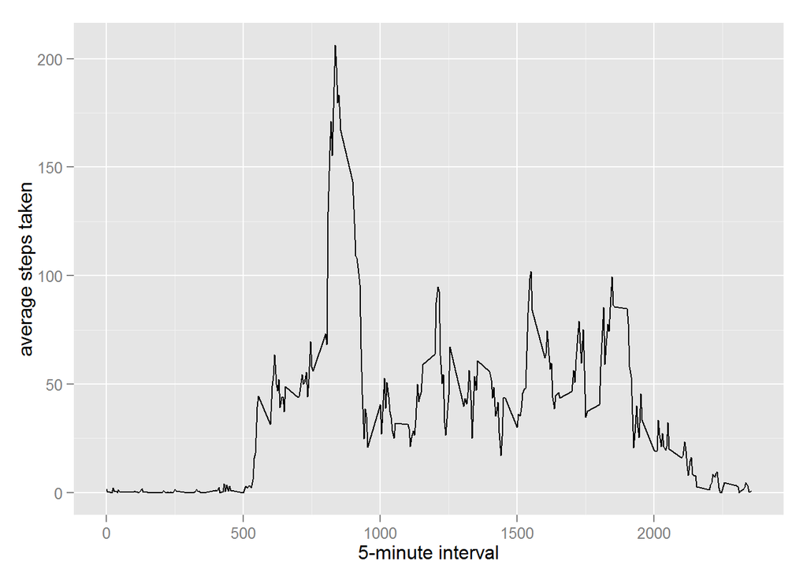

```r
StepsPerTime <- aggregate(x=list(meanSteps=DataFile$steps), by=list(interval=DataFile$interval), FUN=mean, na.rm=TRUE)
ggplot(data=StepsPerTime, aes(x=interval, y=meanSteps)) +
    geom_line() +
    xlab("5-minute interval") +
    ylab("average steps taken")
```

```r
maxsteps <- max(StepsPerTime$meanSteps)
mostSteps <- which.max(StepsPerTime$meanSteps)
timeMostSteps <-  gsub("([0-9]{1,2})([0-9]{2})", "\\1:\\2", StepsPerTime[mostSteps,'interval'])
```

.The most steps occurr at: 8:35 with 206.1698113 average number of steps

## Imputing missing values

- Calculate and report the total number of missing values in the dataset
- Devise a strategy for filling in all of the missing values in the dataset
- Create a new dataset that is equal to the original dataset but with the missing data filled in
- Make a histogram of the total number of steps taken each day

```r
missingvalues <- length(which(is.na(DataFile$steps)))
```

Total missing values is 2304

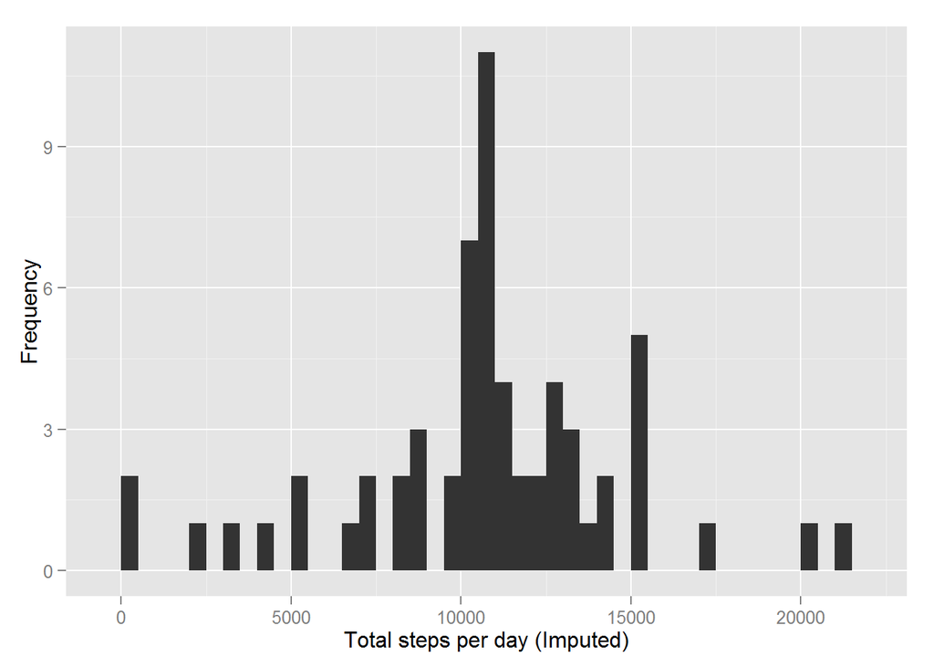

```r
DataFileImputed <- DataFile
DataFileImputed$steps <- impute(DataFile$steps, fun=mean)

Imputedstepsbyday <- tapply(DataFileImputed$steps, DataFileImputed$date, sum)
qplot(Imputedstepsbyday,geom="histogram", xlab='Total steps per day (Imputed)', ylab='Frequency', binwidth=500)
```

### Are there differences in activity patterns between weekdays and weekends?

- Create a new factor variable in the dataset with two levels - “weekday” and “weekend” indicating whether a given date is a weekday or weekend day.
- Make a panel plot containing a time series plot

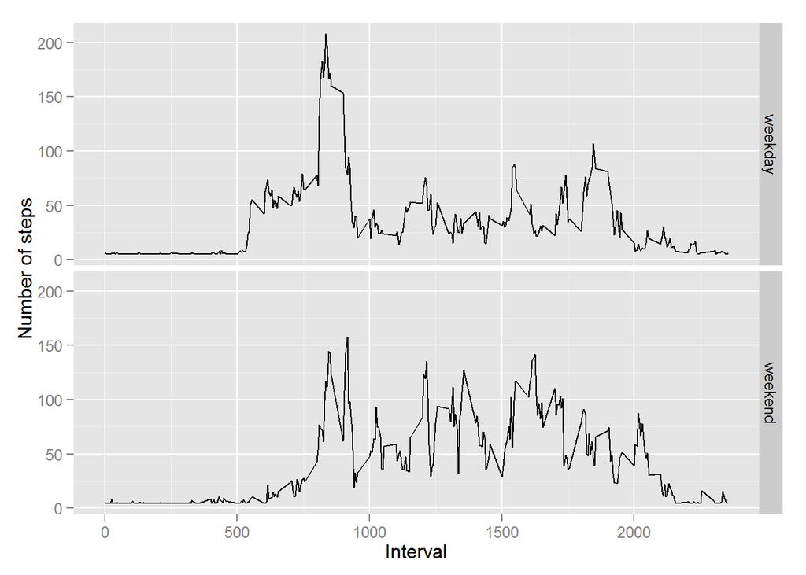

```r
DataFileImputed$dateType <-  ifelse(as.POSIXlt(DataFileImputed$date)$wday %in% c(0,6), 'weekend', 'weekday')

DataImputedAvgActivity <- aggregate(steps ~ interval + dateType, data=DataFileImputed, mean)
ggplot(DataImputedAvgActivity, aes(interval, steps)) +
    geom_line() +
    facet_grid(dateType ~ .) +
    xlab("Interval") +
    ylab("Number of steps")
```